# Project 1 Analysis of Data on Olympic Games 1896 - 2016

Valeriia Ladyhina

2021-11-06

| *The project is a part of course in Statistics from Bioinformatic Institute. In this project I performed analysis of the data of Olympic Games that took place in years from 1896 till 2016.* |
| --- |

**Data collection**

- To merge all files into one data frame you can use next function.

```r
merge_csv_files_in_one_dataframe<-function(){
  do.call(rbind,lapply(setdiff(list.files(pattern = '.csv'),
                               list.files(pattern="combined_")), read.csv))}
```

- Merging files into one data frame named athlete_events_combined.

```r
athlete_events_combined<-merge_csv_files_in_one_dataframe()
```

- Saving created data frame into combined_athlete_events.csv

```r
write.csv(athlete_events_combined,'combined_athlete_events.csv')
```

**EDA**

- Check structure of the data to find out if types of parameters match the expected.

```r
str(athlete_events_combined)
```

Table 1 Structure of the collected data

| variable | length | first_values |
| --- | --- | --- |
| ID | 293507 | 1, 2, 3, 4, 5, 5 |
| Name | 293507 | A Dijiang, A Lamusi, Gunnar Nielsen Aaby, Edgar Lindenau Aabye, Christine Jacoba Aaftink, Christine Jacoba Aaftink |
| Sex | 293507 | M, M, M, M, F, F |
| Age | 293507 | 24, 23, 24, 34, 21, 21 |
| Height | 293507 | 180, 170, NA, NA, 185, 185 |
| Weight | 293507 | 80, 60, NA, NA, 82, 82 |
| Team | 293507 | China, China, Denmark, Denmark/Sweden, Netherlands, Netherlands |
| NOC | 293507 | CHN, CHN, DEN, DEN, NED, NED |
| Games | 293507 | 1992 Summer, 2012 Summer, 1920 Summer, 1900 Summer, 1988 Winter, 1988 Winter |
| Year | 293507 | 1992, 2012, 1920, 1900, 1988, 1988 |
| Season | 293507 | Summer, Summer, Summer, Summer, Winter, Winter |
| City | 293507 | Barcelona, London, Antwerpen, Paris, Calgary, Calgary |
| Sport | 293507 | Basketball, Judo, Football, Tug-Of-War, Speed Skating, Speed Skating |
| Event | 293507 | Basketball Men’s Basketball, Judo Men’s Extra-Lightweight, Football Men’s Football, Tug-Of-War Men’s Tug-Of-War, Speed Skating Women’s 500 metres, Speed Skating Women’s 1,000 metres |
| Medal | 293507 | NA, NA, NA, Gold, NA, NA |

We will change some of the variables’ types: *Sex*, *NOC*, *Team*, *Season* on factor.

```r
athlete_events_combined$Sex<-factor(athlete_events_combined$Sex,levels = c('F','M'))
athlete_events_combined$NOC<-factor(athlete_events_combined$NOC)
athlete_events_combined$Team<-factor(athlete_events_combined$Team)
athlete_events_combined$Season<-factor(athlete_events_combined$Season)
```

- Summary of the data to check weird outliers.

```r
summary(athlete_events_combined)
```

```
##       ID                Name             Sex              Age
##  Length:293507      Length:293507      F   : 79695   Min.   : 10.0
##  Class :character   Class :character   M   :206528   1st Qu.: 21.0
##  Mode  :character   Mode  :character   NA's:  7284   Median : 24.0
##                                                      Mean   : 25.5
##                                                      3rd Qu.: 28.0
##                                                      Max.   :240.0
##                                                      NA's   :17198
##      Height          Weight                  Team             NOC
##  Min.   :127.0   Min.   :  7.00   United States: 18594   USA    : 19651
##  1st Qu.:168.0   1st Qu.: 60.00   France       : 12344   FRA    : 13135
##  Median :175.0   Median : 70.00   Great Britain: 11968   GBR    : 12876
##  Mean   :175.3   Mean   : 70.68   Italy        : 10682   ITA    : 11157
##  3rd Qu.:183.0   3rd Qu.: 79.00   Germany      :  9988   GER    : 10549
##  Max.   :340.0   Max.   :214.00   Canada       :  9639   CAN    : 10119
##  NA's   :70183   NA's   :72955    (Other)      :220292   (Other):216020
##     Games                Year         Season           City
##  Length:293507      Min.   :1896         :  7287   Length:293507
##  Class :character   1st Qu.:1960   Summer:234574   Class :character
##  Mode  :character   Median :1988   Winter: 51646   Mode  :character
##                     Mean   :1979
##                     3rd Qu.:2004
##                     Max.   :2016
##                     NA's   :7287
##     Sport              Event              Medal
##  Length:293507      Length:293507      Length:293507
##  Class :character   Class :character   Class :character
##  Mode  :character   Mode  :character   Mode  :character
##
##
##
##
```

Variable **Height** has strange outliers: **127, 340**, therefore I will check if this data reflects the reality. Firstly I will visualise data.

**Figure 1.** Visualisation of **Height** distribution.

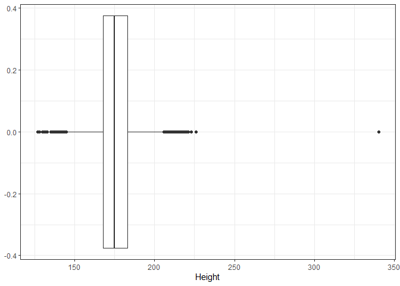

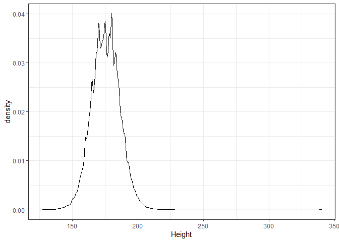

Based on plots it is visible that distribution of height among athlets is normal except one outlier with height 340. I will check the name and real height of this sportmen to fix it.

```r
athlete_events_combined$Name[which(athlete_events_combined$Height == 340)]
```

```
## [1] "Kirsty Leigh Coventry (-Seward)"
```

```r
athlete_events_combined$Height[which(athlete_events_combined$Height == 340)] = 176
```

- The highest sportsmen is Kirsty Leigh Coventry, her real height is 176, so this variable was fixed to the real number.
- The same kind of analysis I will perform on variables **Age** and **Weight**.
- Analysis of **Age**

  **Figure 2.** Visualization of **Age** distribution.

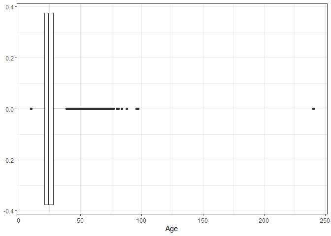

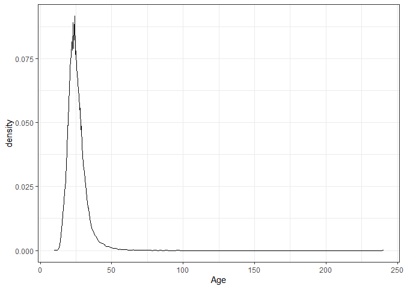

Plots show that there is an outlier with age ~250 years.

- Top 10 variables in *Age*

```r
head(unique(sort(athlete_events_combined$Age, decreasing = TRUE)), n = 10)
```

```
##  [1] 240  97  96  88  84  81  80  77  76  75
```

I will check two eldest sportsmen with age 240 and 97 respectively.

```r
athlete_events_combined$Name[which((athlete_events_combined$Age ==240))]
```

```
## [1] "Flicien Jules mile Courbet"
```

```r
athlete_events_combined$Year[which((athlete_events_combined$Age ==240))]
```

```
## [1] 1912
```

```r
athlete_events_combined$Age[which((athlete_events_combined$Age ==240))] = 24
athlete_events_combined$Name[which((athlete_events_combined$Age ==97))]
```

```
## [1] "John Quincy Adams Ward"
```

```r
athlete_events_combined$Year[which((athlete_events_combined$Age ==97))]
```

```
## [1] 1928
```

There was a typo: Flicien Jules mile Courbet was 24 years during Olympic Games 1912.

- 10 smallest variables in *Age*

```r
head(unique(sort(athlete_events_combined$Age)), n = 10)
```

```
##  [1] 10 11 12 13 14 15 16 17 18 19
```

```r
athlete_events_combined$Name[which((athlete_events_combined$Age ==10))]
```

```
## [1] "Dimitrios Loundras"
```

```r
head(athlete_events_combined$Name[which((athlete_events_combined$Age ==11))], n = 3)
```

```
## [1] "Magdalena Cecilia Colledge"      "Carlos Bienvenido Front Barrera"
## [3] "Luigina Giavotti"
```

The first three youngest sportsmen were checked for the correctness of their age and data reflects reality.

- Analysis of **Weight**

  **Figure 3.** Visualization of **Weight** distribution.

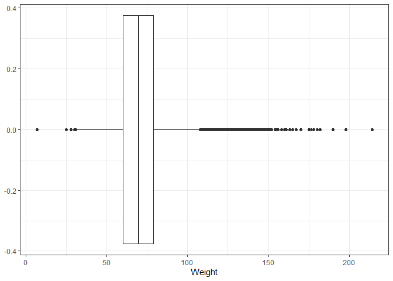

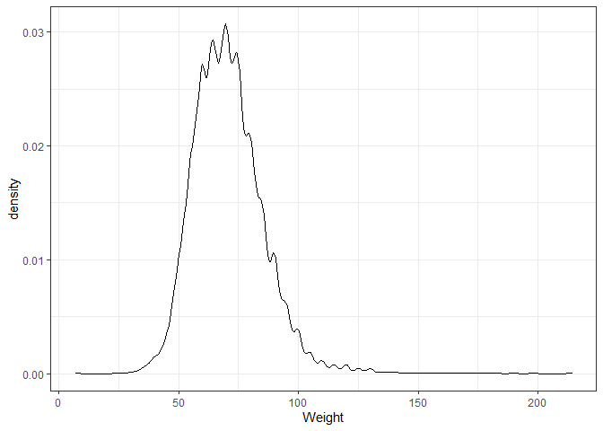

```r
par(mar = c(4, 4, .1, .1))
ggplot(athlete_events_combined,aes(Weight))+
  geom_boxplot()+
  theme_bw()
ggplot(athlete_events_combined,aes(Weight))+
  geom_density()+
  theme_bw()
```

From the plot it is visible that there is an outlier whose wait is ~ 10, the upper numbers of weight do not look extreme. So I will check the correctness of the weight of the lightest sportsman.

- Smallest 10 variables in *Weight*

```r
head(unique(sort(athlete_events_combined$Weight)), n = 10)
```

```
##  [1]  7 25 28 30 31 32 33 34 35 36
```

```r
athlete_events_combined$Name[which(athlete_events_combined$Weight == 7)]
```

```
## [1] "Helmut Lehmann"
```

```r
athlete_events_combined$Weight[which(athlete_events_combined$Weight == 7)] = 77
```

There was a typo in weight of the lightest sportsman and it was fixed.

- In case there are rows that fully consist from NA I will remove them.

```r
athlete_events_combined <- athlete_events_combined[!(grepl('NA',rownames(athlete_events_combined))),]
```

**Tasks**

**Age of the youngest sportsmen among both genders on Olympic games 1992.**

```r
athlete_events_combined %>%
                filter(Year == 1992) %>%
                group_by(Sex) %>%
                summarise(min(Age,na.rm = TRUE)) %>%
                kable(col.names = c('Gender','Minimal Age')) %>%
                kable_styling(full_width = F, "striped", font_size = 10) %>%
                column_spec(1, bold = T, color = 'black')
```

**Answer**

**Table 2** Age of the youngest sportsmen in year 1992

| Gender | Minimal Age |
| --- | --- |
| F | 12 |
| M | 11 |

**Mean and standard deviation of Height among women and men.**

```r
statistics_height<- athlete_events_combined %>%
                    group_by(Sex) %>%
                    summarise(Mean = mean(Height,na.rm = TRUE), SD = sd(Height,na.rm = TRUE)) %>%
                    na.omit()
```

**Answer**

**Table 3** Average height and standard deviation among women and men who participated in Olympic games in years 1896 - 2016.

| Gender | Mean | SD |
| --- | --- | --- |
| F | 167.8663 | 8.813887 |
| M | 178.8775 | 9.415524 |

**Average and standard deviation of Height among women who participated in tennis competion of 2000.**

```r
women_tennis_height_statistics<-athlete_events_combined %>%
  filter(Sport == 'Tennis', Sex == 'F', Year == 2000) %>%
  summarise(Mean = mean(Height,na.rm = TRUE),SD = sd(Height,na.rm = TRUE))
```

**Answer**

**Table 4** Average height and standard deviation among women who participated in Tennis competition in 2000.

| Mean | SD |
| --- | --- |
| 172.0142 | 6.3774 |

**Type of sport of the heaviest sportsman in Athletics 2006**

```r
sport_of_heaviest_sportman<-athlete_events_combined %>%
filter(Year == 2006) %>%
slice(which.max(Weight))
```

**Number of Golden medals that has been aken by women in Years 1980-2010**

```r
number_of_gold_women_80_10<-nrow(athlete_events_combined %>%
filter(Year<=2010, Year>=1980, Sex =="F", Medal == "Gold"))
```

**Answer**

In years from 1980 to 2010 women obtained 2436 of Gold medals.

**Participation of John Aalberg in Olympic Games**

```r
times_John<-length(unique((athlete_events_combined %>%
  filter(Name == 'John Aalberg'))$Year))
```

**Answer**

John Aalberg participated in Olympic Games 2 times.

**Age groups of sportsmen in Olympic Games 2008**

```r
table<-table(cut((athlete_events_combined[athlete_events_combined$Year == 2008,]$Age),seq(15,55,10), include.lowest = TRUE, right = FALSE))
```

**Table 4** Age groups presented in Olympic Games 2008.

```r
kable(table, col.names = c('Age group','Number of participants'))
```

| Age group | Number of participants |
| --- | --- |
| [15,25) | 6771 |
| [25,35) | 6782 |
| [35,45) | 816 |
| [45,55] | 121 |

**Answer**

Based on table 4 the conclusion is that the most abundant age group of sportsmen in 2008 is group of age from 25 to 34.

**Comparison of sport variety between years 1994 and 2002**

```r
difference_number_of_sports_2002_1994<-length(unique((athlete_events_combined %>%                                         filter(Year==2002))$Sport))-length(unique((athlete_events_combined %>%
                                        filter(Year==1994))$Sport))
```

**Answer**

In year 2002 the range of presented types of sport was wider on 3 than in year 1994.

**Countries with most gold, silver and bronze medals during winter and summer seasons**

```r
winter_summer_medals_abundance<-athlete_events_combined %>%
  filter(Medal!='',Medal!='NA') %>%
  group_by(Season,Medal,NOC)%>%
  summarise(n = n()) %>%
  slice_max(order_by = n, n = 3)
```

**Answer**

**Table 5** Top three countries in number of gold, silver, bronze medals during winter and summer seasons.

| Season | Medal | NOC | n |
| --- | --- | --- | --- |
| Summer | Bronze | USA | 1246 |
| Summer | Bronze | GER | 709 |
| Summer | Bronze | GBR | 649 |
| Summer | Gold | USA | 2584 |
| Summer | Gold | URS | 873 |
| Summer | Gold | GBR | 664 |
| Summer | Silver | USA | 1394 |
| Summer | Silver | GBR | 759 |
| Summer | Silver | URS | 673 |
| Winter | Bronze | FIN | 222 |
| Winter | Bronze | SWE | 185 |
| Winter | Bronze | USA | 167 |
| Winter | Gold | CAN | 317 |
| Winter | Gold | URS | 282 |
| Winter | Gold | USA | 175 |
| Winter | Silver | USA | 316 |
| Winter | Silver | CAN | 207 |
| Winter | Silver | NOR | 171 |

**Z-scaling for variable Height**

```r
Height_z_scores<-scale(athlete_events_combined$Height)
```

**Editional Tasks**

**Min-max-scaling for variable Height**

```r
min_max_scale <- function(x) {
  (x - min(x, na.rm = TRUE)) / (max(x, na.rm = TRUE) - min(x, na.rm = TRUE))
}
Height_min_max_scaled<-(athlete_events_combined %>%
  mutate(Height_min_max_scaled = min_max_scale(Height)))$Height
```

**Comparison of height, weight, age of men and women who participated in winter season games.**

**Figure 4** Check for normality of distribution of **Height**

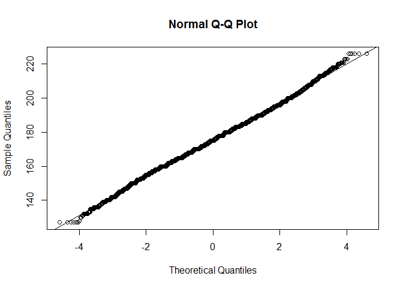

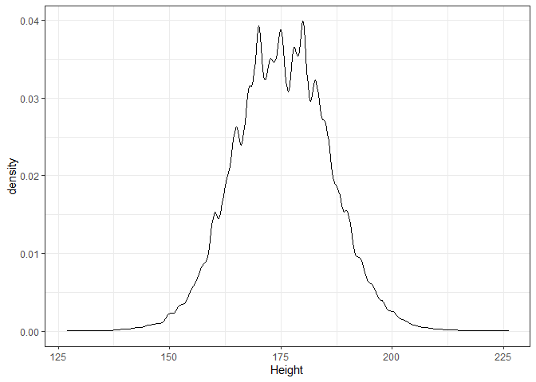

**Figure 5** Check for normality of distribution of **Weight**

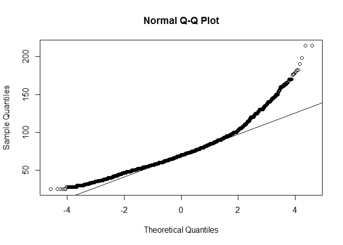

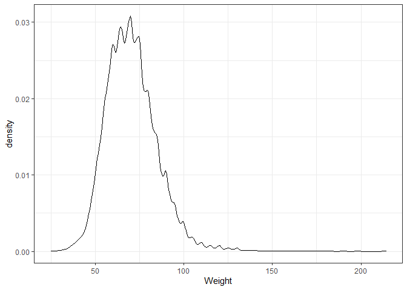

**Figure 6** Check for normality of distribution of **Age**

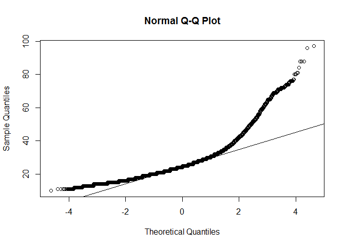

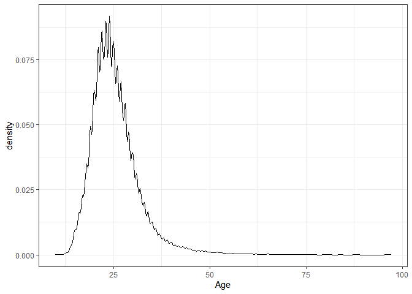

```r
height_data<-select(athlete_events_combined,c(Sex,Height))
height_data$Sex<-factor(height_data$Sex, levels = c('F','M'))
height_data<- drop_na(height_data)
#group_size
length(height_data)
```

```
## [1] 2
```

```r
#t-test Height
t.test(Height~Sex, data = height_data)
```

```
##
##  Welch Two Sample t-test
##
## data:  Height by Sex
## t = -269.97, df = 150673, p-value < 2.2e-16
## alternative hypothesis: true difference in means is not equal to 0
## 95 percent confidence interval:
##  -11.09116 -10.93127
## sample estimates:
## mean in group F mean in group M
##        167.8663        178.8775
```

```r
weight_data<-select(athlete_events_combined,c(Sex,Weight))
weight_data$Sex<-factor(weight_data$Sex, levels = c('F','M'))
weight_data<- drop_na(weight_data)
#group_size
length(weight_data)
```

```
## [1] 2
```

```r
#wilcox-test weight
wilcox.test(Weight~Sex, data = weight_data)
```

```
##
##  Wilcoxon rank sum test with continuity correction
##
## data:  Weight by Sex
## W = 1659761595, p-value < 2.2e-16
## alternative hypothesis: true location shift is not equal to 0
```

```r
age_data<-select(athlete_events_combined,c(Sex,Age))
age_data$Sex<-factor(age_data$Sex, levels = c('F','M'))
age_data<- drop_na(age_data)
#group_size
length(age_data)
```

```
## [1] 2
```

```r
#wilcox-test age
wilcox.test(Age~Sex, data = age_data)
```

```
##
##  Wilcoxon rank sum test with continuity correction
##
## data:  Age by Sex
## W = 5.95e+09, p-value < 2.2e-16
## alternative hypothesis: true location shift is not equal to 0
```

**Figure 7** Comparison of height, weight and age inbetween female and male athletes.

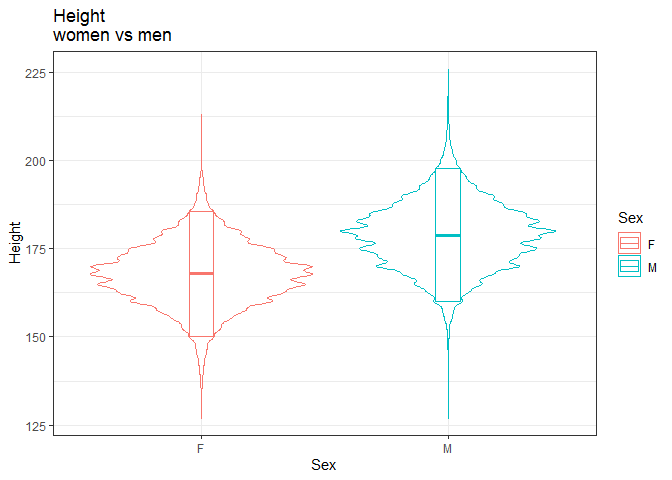

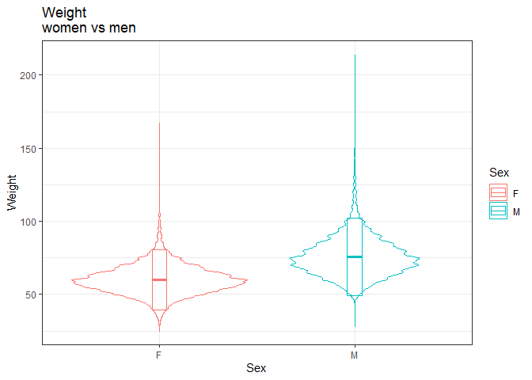

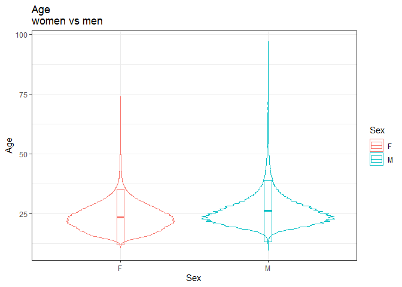

```r
ggplot(height_data,aes(Sex,Height, color = Sex))+
  geom_violin()+
  stat_summary(fun.data="mean_sdl",
                              geom="crossbar", width=0.1 )+
  ggtitle('Height\nwomen vs men',)+
  theme_bw()
ggplot(weight_data,aes(Sex,Weight, color = Sex))+
  geom_violin()+
  stat_summary(fun.data="mean_sdl",
                 geom="crossbar", width=0.075 )+
  ggtitle('Weight\nwomen vs men',)+
  theme_bw()
    ggplot(age_data,aes(Sex,Age, color = Sex))+
    geom_violin()+
    stat_summary(fun.data="mean_sdl",
                 geom="crossbar", width=0.05 )+
    ggtitle('Age\nwomen vs men',)+
    theme_bw()
```

**Conclusion**

To perform analysis on height, weight and age of sportsmen depanding on there gender I checked normality of distribution of variables of interest based on QQ plot and density plot. Figure 4 showed that height distributed normally therefore to check H0 (There is no difference between height of men and women) I performed t-test. As p-value < 2.2e-16, the difference is significant, height of men is higher than of women. QQ plot of weight and age (Figure5,6) are skewed therefore for further analysis I performed non-parametric test Mann-Whitney. For both variables of interest the result showed p-value < 2.2e-16, therefore differences (weight of women lower than weight of men, the same as age) are significant. Visualisation of distribution of height,weight and age in depandancy with gender is shown on Figure 7.

**Correlation between Team and Medal**

```r
result_team_medal<- athlete_events_combined %>%
  group_by(Year, NOC) %>%
  na.omit() %>%
  filter(Medal!="", Year >=2000, Season == "Summer") %>%
  summarise(Count = n()) %>%
  arrange(-Count)
result_team_medal<- result_team_medal %>%
  filter(Count>=20)
```

**Figure 8** Number of gold, silver and bronze medals per country

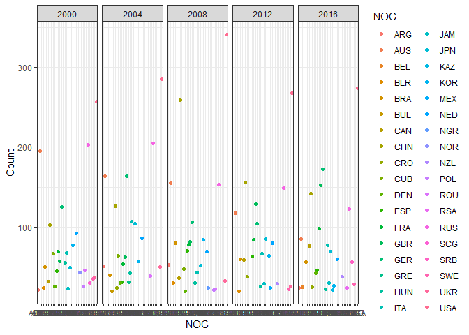

**Conclusion**

To analyze if there any dependency between NOC and Medals I visualized number of obtained medals during the period from 2000 to 2016 only for summer season. Such choice of time line is based idea that in earlier years not so many teams were involved into Olympic games and to reduce the possible difference inbetween number of obtained medals by countries that played from first Olympic Games and countries that joined later. Figure 8 showing that through the years USA obtains the majority of the medals,other countries that takes the place in leader positions are Australia, China and Russia as for the rest analyzed countries dependancy between NOC and number of medals is not visible.

**Correlation between Height and Weight**

**H0 There is no correlation between height and weight.H1 There is correlation between height and weight of sportmen.**

**Figure 9** Correlation between height and weight of sportsmen.

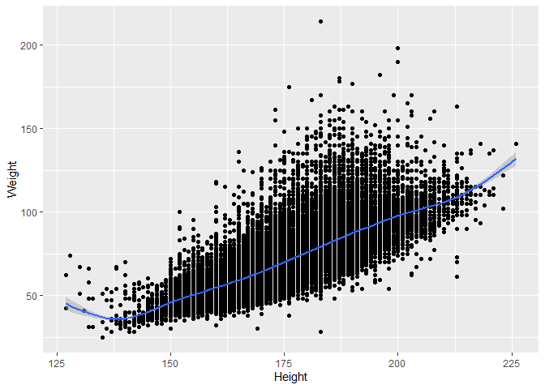

```r
cor.test(athlete_events_combined$Height,athlete_events_combined$Weight)
```

```
##
##  Pearson's product-moment correlation
##
## data:  athlete_events_combined$Height and athlete_events_combined$Weight
## t = 618.5, df = 219068, p-value < 2.2e-16
## alternative hypothesis: true correlation is not equal to 0
## 95 percent confidence interval:
##  0.7958829 0.7989326
## sample estimates:
##       cor
## 0.7974128
```

**Conclusion**

Based on results of Pearson correlation test (p-value < 2.2e-16) there is strong positive correlation (cor 0.7974128) between height and weight of sportsmen.

**H0 The gender does not effect the chance to get Gold in Tennis competition H1 Gender affects the ability of sportsmen to get Gold medal.**

```r
athlete_tennis <- athlete_events_combined %>% filter(Sport == 'Tennis')
women_gold <- athlete_tennis %>%
  filter(Sex == 'F', Medal == 'Gold') %>%
  summarise(n())
women_all <- athlete_tennis %>%
  filter(Sex == 'F') %>%
  summarise(n())
men_gold <- athlete_tennis %>%
  filter(Sex == 'M', Medal == 'Gold') %>%
  summarise(n())
men_all <- athlete_tennis %>%
  filter(Sex == 'M') %>%
  summarise(n())
women_tennis <- women_gold[1,] / women_all[1,]
men_tennis <- men_gold[1,] / men_all[1,]
tennis_table = data.frame(women_tennis = women_tennis, men_tennis = men_tennis)
chisq.test(tennis_table)
```

```
##
##  Chi-squared test for given probabilities
##
## data:  tennis_table
## X-squared = 0.00031311, df = 1, p-value = 0.9859
```

**Conclusion**

The results of chi-squared tests (X-squared = 0.00031311, p-value = 0.9859) support the H0 hypotesis that gender does not affect the chance of sportsman to get Gold, which is logical as by now competition is divided into groups based on Sex.